# Risk Factor Analysis

## Outcome Variable

**Outcome Variable:** haz

## Predictor Variables

**Intervention Variable:** hdlvry

**Adjustment Set:**

- arm
- sex
- W_mage
- meducyrs
- feducyrs
- hhwealth_quart
- single
- W_nrooms
- brthmon
- W_parity
- impsan
- delta_W_mage
- delta_meducyrs
- delta_feducyrs
- delta_hhwealth_quart
- delta_single
- delta_W_nrooms
- delta_brthmon
- delta_W_parity
- delta_impsan

## Stratifying Variables

The analysis was stratified on these variable(s):

- agecat
- studyid
- country

## Data Summary

| agecat | studyid | country | hdlvry | n_cell | n | outcome_variable |
| --- | --- | --- | --- | --- | --- | --- |
| Birth | CMC-V-BCS-2002 | INDIA | 0 | 92 | 92 | haz |
| Birth | CMC-V-BCS-2002 | INDIA | 1 | 0 | 92 | haz |
| Birth | COHORTS | INDIA | 0 | 2938 | 4694 | haz |
| Birth | COHORTS | INDIA | 1 | 1756 | 4694 | haz |
| Birth | EE | PAKISTAN | 0 | 161 | 238 | haz |
| Birth | EE | PAKISTAN | 1 | 77 | 238 | haz |
| Birth | GMS-Nepal | NEPAL | 0 | 157 | 646 | haz |
| Birth | GMS-Nepal | NEPAL | 1 | 489 | 646 | haz |
| Birth | IRC | INDIA | 0 | 381 | 388 | haz |
| Birth | IRC | INDIA | 1 | 7 | 388 | haz |
| Birth | JiVitA-3 | BANGLADESH | 0 | 30 | 334 | haz |
| Birth | JiVitA-3 | BANGLADESH | 1 | 304 | 334 | haz |
| Birth | JiVitA-4 | BANGLADESH | 0 | 554 | 2808 | haz |
| Birth | JiVitA-4 | BANGLADESH | 1 | 2254 | 2808 | haz |
| Birth | NIH-Crypto | BANGLADESH | 0 | 567 | 732 | haz |
| Birth | NIH-Crypto | BANGLADESH | 1 | 165 | 732 | haz |
| Birth | PROVIDE | BANGLADESH | 0 | 391 | 539 | haz |
| Birth | PROVIDE | BANGLADESH | 1 | 148 | 539 | haz |
| Birth | SAS-CompFeed | INDIA | 0 | 124 | 1085 | haz |
| Birth | SAS-CompFeed | INDIA | 1 | 961 | 1085 | haz |
| 6 months | CMC-V-BCS-2002 | INDIA | 0 | 358 | 366 | haz |
| 6 months | CMC-V-BCS-2002 | INDIA | 1 | 8 | 366 | haz |
| 6 months | COHORTS | INDIA | 0 | 2900 | 4699 | haz |
| 6 months | COHORTS | INDIA | 1 | 1799 | 4699 | haz |
| 6 months | EE | PAKISTAN | 0 | 250 | 371 | haz |
| 6 months | EE | PAKISTAN | 1 | 121 | 371 | haz |
| 6 months | GMS-Nepal | NEPAL | 0 | 129 | 528 | haz |
| 6 months | GMS-Nepal | NEPAL | 1 | 399 | 528 | haz |
| 6 months | IRC | INDIA | 0 | 399 | 407 | haz |
| 6 months | IRC | INDIA | 1 | 8 | 407 | haz |
| 6 months | JiVitA-3 | BANGLADESH | 0 | 39 | 332 | haz |
| 6 months | JiVitA-3 | BANGLADESH | 1 | 293 | 332 | haz |
| 6 months | JiVitA-4 | BANGLADESH | 0 | 1081 | 4038 | haz |
| 6 months | JiVitA-4 | BANGLADESH | 1 | 2957 | 4038 | haz |
| 6 months | NIH-Crypto | BANGLADESH | 0 | 554 | 715 | haz |
| 6 months | NIH-Crypto | BANGLADESH | 1 | 161 | 715 | haz |
| 6 months | PROVIDE | BANGLADESH | 0 | 450 | 604 | haz |
| 6 months | PROVIDE | BANGLADESH | 1 | 154 | 604 | haz |
| 6 months | SAS-CompFeed | INDIA | 0 | 147 | 1091 | haz |
| 6 months | SAS-CompFeed | INDIA | 1 | 944 | 1091 | haz |
| 6 months | SAS-FoodSuppl | INDIA | 0 | 76 | 380 | haz |
| 6 months | SAS-FoodSuppl | INDIA | 1 | 304 | 380 | haz |
| 6 months | TanzaniaChild2 | TANZANIA, UNITED REPUBLIC OF | 0 | 1889 | 1921 | haz |
| 6 months | TanzaniaChild2 | TANZANIA, UNITED REPUBLIC OF | 1 | 32 | 1921 | haz |
| 24 months | CMC-V-BCS-2002 | INDIA | 0 | 360 | 368 | haz |
| 24 months | CMC-V-BCS-2002 | INDIA | 1 | 8 | 368 | haz |
| 24 months | COHORTS | INDIA | 0 | 2233 | 3556 | haz |
| 24 months | COHORTS | INDIA | 1 | 1323 | 3556 | haz |
| 24 months | EE | PAKISTAN | 0 | 112 | 166 | haz |
| 24 months | EE | PAKISTAN | 1 | 54 | 166 | haz |
| 24 months | GMS-Nepal | NEPAL | 0 | 118 | 456 | haz |
| 24 months | GMS-Nepal | NEPAL | 1 | 338 | 456 | haz |
| 24 months | IRC | INDIA | 0 | 401 | 409 | haz |
| 24 months | IRC | INDIA | 1 | 8 | 409 | haz |
| 24 months | JiVitA-3 | BANGLADESH | 0 | 35 | 291 | haz |
| 24 months | JiVitA-3 | BANGLADESH | 1 | 256 | 291 | haz |
| 24 months | JiVitA-4 | BANGLADESH | 0 | 1033 | 4005 | haz |
| 24 months | JiVitA-4 | BANGLADESH | 1 | 2972 | 4005 | haz |
| 24 months | NIH-Crypto | BANGLADESH | 0 | 391 | 514 | haz |
| 24 months | NIH-Crypto | BANGLADESH | 1 | 123 | 514 | haz |
| 24 months | PROVIDE | BANGLADESH | 0 | 433 | 578 | haz |
| 24 months | PROVIDE | BANGLADESH | 1 | 145 | 578 | haz |
| 24 months | TanzaniaChild2 | TANZANIA, UNITED REPUBLIC OF | 0 | 6 | 6 | haz |
| 24 months | TanzaniaChild2 | TANZANIA, UNITED REPUBLIC OF | 1 | 0 | 6 | haz |

The following strata were considered:

- agecat: 24 months, studyid: CMC-V-BCS-2002, country: INDIA
- agecat: 24 months, studyid: COHORTS, country: INDIA
- agecat: 24 months, studyid: EE, country: PAKISTAN
- agecat: 24 months, studyid: GMS-Nepal, country: NEPAL
- agecat: 24 months, studyid: IRC, country: INDIA
- agecat: 24 months, studyid: JiVitA-3, country: BANGLADESH
- agecat: 24 months, studyid: JiVitA-4, country: BANGLADESH
- agecat: 24 months, studyid: NIH-Crypto, country: BANGLADESH
- agecat: 24 months, studyid: PROVIDE, country: BANGLADESH
- agecat: 24 months, studyid: TanzaniaChild2, country: TANZANIA, UNITED REPUBLIC OF
- agecat: 6 months, studyid: CMC-V-BCS-2002, country: INDIA
- agecat: 6 months, studyid: COHORTS, country: INDIA
- agecat: 6 months, studyid: EE, country: PAKISTAN
- agecat: 6 months, studyid: GMS-Nepal, country: NEPAL
- agecat: 6 months, studyid: IRC, country: INDIA
- agecat: 6 months, studyid: JiVitA-3, country: BANGLADESH
- agecat: 6 months, studyid: JiVitA-4, country: BANGLADESH
- agecat: 6 months, studyid: NIH-Crypto, country: BANGLADESH
- agecat: 6 months, studyid: PROVIDE, country: BANGLADESH
- agecat: 6 months, studyid: SAS-CompFeed, country: INDIA
- agecat: 6 months, studyid: SAS-FoodSuppl, country: INDIA
- agecat: 6 months, studyid: TanzaniaChild2, country: TANZANIA, UNITED REPUBLIC OF
- agecat: Birth, studyid: CMC-V-BCS-2002, country: INDIA
- agecat: Birth, studyid: COHORTS, country: INDIA
- agecat: Birth, studyid: EE, country: PAKISTAN
- agecat: Birth, studyid: GMS-Nepal, country: NEPAL
- agecat: Birth, studyid: IRC, country: INDIA
- agecat: Birth, studyid: JiVitA-3, country: BANGLADESH
- agecat: Birth, studyid: JiVitA-4, country: BANGLADESH
- agecat: Birth, studyid: NIH-Crypto, country: BANGLADESH
- agecat: Birth, studyid: PROVIDE, country: BANGLADESH
- agecat: Birth, studyid: SAS-CompFeed, country: INDIA

### Dropped Strata

- agecat: Birth, studyid: CMC-V-BCS-2002, country: INDIA
- agecat: 24 months, studyid: TanzaniaChild2, country: TANZANIA, UNITED REPUBLIC OF

## Methods Detail

We’re interested in the causal parameters $E[Y_a]$ for all values of $a \in \mathcal{A}$. These parameters represent the mean outcome if, possibly contrary to fact, we intervened to set all units to have $A=a$. Under the randomization and positivity assumptions, these are identified by the statistical parameters $\psi_a=E_W[E_{Y|A,W}(Y|A=a,W)]$. In addition, we’re interested in the mean of $Y$, $E[Y]$ under no intervention (the observed mean). We will estimate these parameters by using SuperLearner to fit the relevant likelihood factors – $E_{Y|A,W}(Y|A=a,W)$ and $p(A=a|W)$, and then updating our likelihood fit using a joint TMLE.

For unadjusted analyses ($W=\{\}$), initial likelihoods were estimated using Lrnr_glm to estimate the simple $E(Y|A)$ and Lrnr_mean to estimate $p(A)$. For adjusted analyses, a small library containing Lrnr_glmnet, Lrnr_xgboost, and Lrnr_mean was used.

Having estimated these parameters, we will then use the delta method to estimate relative risks and attributable risks relative to a prespecified baseline level of $A$.

# Results Detail

## Results Plots

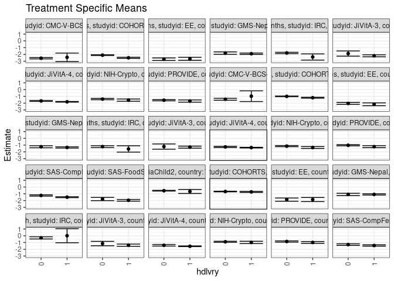

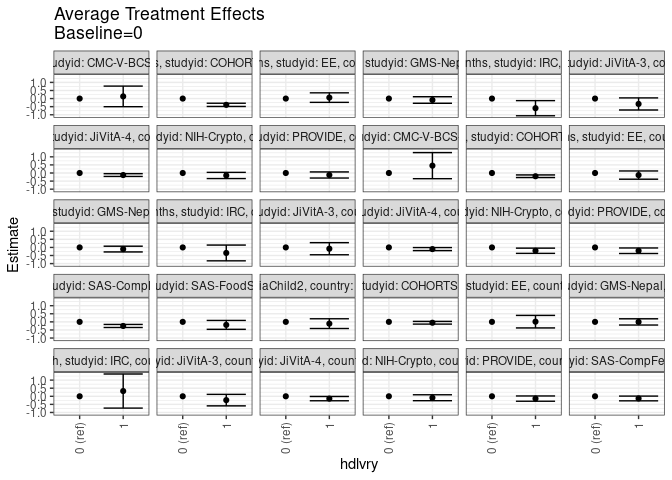

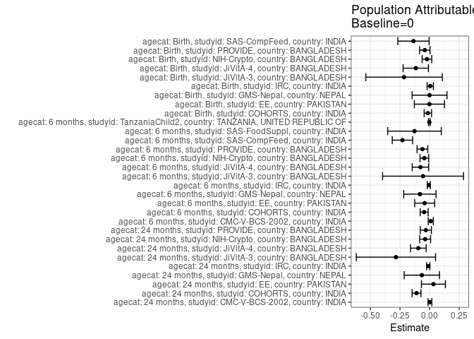

## Results Table

### Parameter: TSM

| agecat | studyid | country | intervention_level | baseline_level | estimate | ci_lower | ci_upper |
| --- | --- | --- | --- | --- | --- | --- | --- |
| Birth | COHORTS | INDIA | 0 | NA | -0.6617929 | -0.7086055 | -0.6149802 |
| Birth | COHORTS | INDIA | 1 | NA | -0.7163665 | -0.7854151 | -0.6473178 |
| Birth | EE | PAKISTAN | 0 | NA | -1.8600562 | -2.0991534 | -1.6209589 |
| Birth | EE | PAKISTAN | 1 | NA | -1.8477629 | -2.1522983 | -1.5432275 |
| Birth | GMS-Nepal | NEPAL | 0 | NA | -1.0904803 | -1.2593949 | -0.9215656 |
| Birth | GMS-Nepal | NEPAL | 1 | NA | -1.0942193 | -1.1888577 | -0.9995808 |
| Birth | IRC | INDIA | 0 | NA | -0.3138845 | -0.4765233 | -0.1512457 |
| Birth | IRC | INDIA | 1 | NA | 0.0100000 | -1.0310607 | 1.0510607 |
| Birth | JiVitA-3 | BANGLADESH | 0 | NA | -1.1526561 | -1.4761513 | -0.8291608 |
| Birth | JiVitA-3 | BANGLADESH | 1 | NA | -1.3897039 | -1.5523740 | -1.2270337 |
| Birth | JiVitA-4 | BANGLADESH | 0 | NA | -1.4050081 | -1.5255807 | -1.2844355 |
| Birth | JiVitA-4 | BANGLADESH | 1 | NA | -1.5489782 | -1.6035435 | -1.4944129 |
| Birth | NIH-Crypto | BANGLADESH | 0 | NA | -0.8874609 | -0.9671277 | -0.8077941 |
| Birth | NIH-Crypto | BANGLADESH | 1 | NA | -0.9773037 | -1.1427487 | -0.8118588 |
| Birth | PROVIDE | BANGLADESH | 0 | NA | -0.8446131 | -0.9346179 | -0.7546084 |
| Birth | PROVIDE | BANGLADESH | 1 | NA | -0.9868391 | -1.1216407 | -0.8520375 |
| Birth | SAS-CompFeed | INDIA | 0 | NA | -1.3043049 | -1.4241966 | -1.1844132 |
| Birth | SAS-CompFeed | INDIA | 1 | NA | -1.4383865 | -1.5399229 | -1.3368500 |
| 6 months | CMC-V-BCS-2002 | INDIA | 0 | NA | -1.4288687 | -1.5726614 | -1.2850760 |
| 6 months | CMC-V-BCS-2002 | INDIA | 1 | NA | -0.9754167 | -1.7693720 | -0.1814613 |
| 6 months | COHORTS | INDIA | 0 | NA | -0.9997751 | -1.0477117 | -0.9518386 |
| 6 months | COHORTS | INDIA | 1 | NA | -1.1995710 | -1.2647278 | -1.1344142 |
| 6 months | EE | PAKISTAN | 0 | NA | -2.0412784 | -2.1885557 | -1.8940010 |
| 6 months | EE | PAKISTAN | 1 | NA | -2.1698493 | -2.3779353 | -1.9617632 |
| 6 months | GMS-Nepal | NEPAL | 0 | NA | -1.2477259 | -1.3981685 | -1.0972834 |
| 6 months | GMS-Nepal | NEPAL | 1 | NA | -1.3486957 | -1.4424773 | -1.2549142 |
| 6 months | IRC | INDIA | 0 | NA | -1.2276901 | -1.3618868 | -1.0934933 |
| 6 months | IRC | INDIA | 1 | NA | -1.5693750 | -2.0379505 | -1.1007995 |
| 6 months | JiVitA-3 | BANGLADESH | 0 | NA | -1.2234202 | -1.6126078 | -0.8342327 |
| 6 months | JiVitA-3 | BANGLADESH | 1 | NA | -1.3025524 | -1.4529610 | -1.1521438 |
| 6 months | JiVitA-4 | BANGLADESH | 0 | NA | -1.2707322 | -1.3540410 | -1.1874235 |
| 6 months | JiVitA-4 | BANGLADESH | 1 | NA | -1.3736382 | -1.4235339 | -1.3237425 |
| 6 months | NIH-Crypto | BANGLADESH | 0 | NA | -1.1544269 | -1.2371523 | -1.0717015 |
| 6 months | NIH-Crypto | BANGLADESH | 1 | NA | -1.3603182 | -1.4991665 | -1.2214699 |
| 6 months | PROVIDE | BANGLADESH | 0 | NA | -1.0311289 | -1.1166289 | -0.9456288 |
| 6 months | PROVIDE | BANGLADESH | 1 | NA | -1.2356807 | -1.3829975 | -1.0883638 |
| 6 months | SAS-CompFeed | INDIA | 0 | NA | -1.2403474 | -1.3346382 | -1.1460565 |
| 6 months | SAS-CompFeed | INDIA | 1 | NA | -1.4941568 | -1.5656568 | -1.4226568 |
| 6 months | SAS-FoodSuppl | INDIA | 0 | NA | -1.7709935 | -2.0128068 | -1.5291802 |
| 6 months | SAS-FoodSuppl | INDIA | 1 | NA | -1.9575040 | -2.0882691 | -1.8267388 |
| 6 months | TanzaniaChild2 | TANZANIA, UNITED REPUBLIC OF | 0 | NA | -0.5419450 | -0.5932753 | -0.4906147 |
| 6 months | TanzaniaChild2 | TANZANIA, UNITED REPUBLIC OF | 1 | NA | -0.6514371 | -0.9484955 | -0.3543786 |
| 24 months | CMC-V-BCS-2002 | INDIA | 0 | NA | -2.5640139 | -2.6645275 | -2.4635003 |
| 24 months | CMC-V-BCS-2002 | INDIA | 1 | NA | -2.4300000 | -3.0592261 | -1.8007739 |
| 24 months | COHORTS | INDIA | 0 | NA | -2.1115124 | -2.1651115 | -2.0579133 |
| 24 months | COHORTS | INDIA | 1 | NA | -2.4994793 | -2.5839655 | -2.4149930 |
| 24 months | EE | PAKISTAN | 0 | NA | -2.7095613 | -2.8994417 | -2.5196809 |
| 24 months | EE | PAKISTAN | 1 | NA | -2.6490570 | -2.8723690 | -2.4257449 |
| 24 months | GMS-Nepal | NEPAL | 0 | NA | -1.8064654 | -1.9816802 | -1.6312506 |
| 24 months | GMS-Nepal | NEPAL | 1 | NA | -1.8951580 | -1.9948752 | -1.7954407 |
| 24 months | IRC | INDIA | 0 | NA | -1.7871446 | -1.8820825 | -1.6922068 |
| 24 months | IRC | INDIA | 1 | NA | -2.3818750 | -2.8405973 | -1.9231527 |
| 24 months | JiVitA-3 | BANGLADESH | 0 | NA | -1.8726116 | -2.2539004 | -1.4913229 |
| 24 months | JiVitA-3 | BANGLADESH | 1 | NA | -2.2049716 | -2.3492647 | -2.0606785 |
| 24 months | JiVitA-4 | BANGLADESH | 0 | NA | -1.6774621 | -1.7541324 | -1.6007919 |
| 24 months | JiVitA-4 | BANGLADESH | 1 | NA | -1.8039642 | -1.8478058 | -1.7601226 |
| 24 months | NIH-Crypto | BANGLADESH | 0 | NA | -1.4038327 | -1.5020223 | -1.3056432 |
| 24 months | NIH-Crypto | BANGLADESH | 1 | NA | -1.5558891 | -1.7212562 | -1.3905220 |
| 24 months | PROVIDE | BANGLADESH | 0 | NA | -1.5707515 | -1.6671406 | -1.4743624 |
| 24 months | PROVIDE | BANGLADESH | 1 | NA | -1.6937294 | -1.8581881 | -1.5292707 |

### Parameter: E(Y)

| agecat | studyid | country | intervention_level | baseline_level | estimate | ci_lower | ci_upper |
| --- | --- | --- | --- | --- | --- | --- | --- |
| Birth | COHORTS | INDIA | NA | NA | -0.6762420 | -0.7093108 | -0.6431732 |
| Birth | EE | PAKISTAN | NA | NA | -1.8614286 | -2.0501173 | -1.6727398 |
| Birth | GMS-Nepal | NEPAL | NA | NA | -1.0909443 | -1.1734385 | -1.0084500 |
| Birth | IRC | INDIA | NA | NA | -0.3080412 | -0.4687931 | -0.1472894 |
| Birth | JiVitA-3 | BANGLADESH | NA | NA | -1.3684731 | -1.5219775 | -1.2149687 |
| Birth | JiVitA-4 | BANGLADESH | NA | NA | -1.5216453 | -1.5715117 | -1.4717789 |
| Birth | NIH-Crypto | BANGLADESH | NA | NA | -0.9094945 | -0.9809370 | -0.8380521 |
| Birth | PROVIDE | BANGLADESH | NA | NA | -0.8851020 | -0.9601332 | -0.8100709 |
| Birth | SAS-CompFeed | INDIA | NA | NA | -1.4401843 | -1.5334809 | -1.3468878 |
| 6 months | CMC-V-BCS-2002 | INDIA | NA | NA | -1.4189572 | -1.5607165 | -1.2771979 |
| 6 months | COHORTS | INDIA | NA | NA | -1.0458076 | -1.0793244 | -1.0122908 |
| 6 months | EE | PAKISTAN | NA | NA | -2.0826460 | -2.2022514 | -1.9630406 |
| 6 months | GMS-Nepal | NEPAL | NA | NA | -1.3296275 | -1.4093037 | -1.2499514 |
| 6 months | IRC | INDIA | NA | NA | -1.2344062 | -1.3658524 | -1.1029600 |
| 6 months | JiVitA-3 | BANGLADESH | NA | NA | -1.2787349 | -1.4248268 | -1.1326431 |
| 6 months | JiVitA-4 | BANGLADESH | NA | NA | -1.3481303 | -1.3904710 | -1.3057895 |
| 6 months | NIH-Crypto | BANGLADESH | NA | NA | -1.1986783 | -1.2700937 | -1.1272630 |
| 6 months | PROVIDE | BANGLADESH | NA | NA | -1.0916915 | -1.1661176 | -1.0172654 |
| 6 months | SAS-CompFeed | INDIA | NA | NA | -1.4699588 | -1.5446559 | -1.3952616 |
| 6 months | SAS-FoodSuppl | INDIA | NA | NA | -1.8986842 | -2.0118892 | -1.7854792 |
| 6 months | TanzaniaChild2 | TANZANIA, UNITED REPUBLIC OF | NA | NA | -0.5440573 | -0.5945614 | -0.4935533 |
| 24 months | CMC-V-BCS-2002 | INDIA | NA | NA | -2.5611005 | -2.6603759 | -2.4618252 |
| 24 months | COHORTS | INDIA | NA | NA | -2.2218335 | -2.2619519 | -2.1817151 |
| 24 months | EE | PAKISTAN | NA | NA | -2.6770382 | -2.8210532 | -2.5330231 |
| 24 months | GMS-Nepal | NEPAL | NA | NA | -1.8717982 | -1.9591776 | -1.7844189 |
| 24 months | IRC | INDIA | NA | NA | -1.7987775 | -1.8923914 | -1.7051636 |
| 24 months | JiVitA-3 | BANGLADESH | NA | NA | -2.1571821 | -2.2993457 | -2.0150186 |
| 24 months | JiVitA-4 | BANGLADESH | NA | NA | -1.7725918 | -1.8111207 | -1.7340629 |
| 24 months | NIH-Crypto | BANGLADESH | NA | NA | -1.4412646 | -1.5249156 | -1.3576135 |
| 24 months | PROVIDE | BANGLADESH | NA | NA | -1.6024221 | -1.6857420 | -1.5191023 |

### Parameter: ATE

| agecat | studyid | country | intervention_level | baseline_level | estimate | ci_lower | ci_upper |
| --- | --- | --- | --- | --- | --- | --- | --- |
| Birth | COHORTS | INDIA | 0 | 0 | 0.0000000 | 0.0000000 | 0.0000000 |
| Birth | COHORTS | INDIA | 1 | 0 | -0.0545736 | -0.1376623 | 0.0285151 |
| Birth | EE | PAKISTAN | 0 | 0 | 0.0000000 | 0.0000000 | 0.0000000 |
| Birth | EE | PAKISTAN | 1 | 0 | 0.0122933 | -0.3751137 | 0.3997003 |
| Birth | GMS-Nepal | NEPAL | 0 | 0 | 0.0000000 | 0.0000000 | 0.0000000 |
| Birth | GMS-Nepal | NEPAL | 1 | 0 | -0.0037390 | -0.1965065 | 0.1890286 |
| Birth | IRC | INDIA | 0 | 0 | 0.0000000 | 0.0000000 | 0.0000000 |
| Birth | IRC | INDIA | 1 | 0 | 0.3238845 | -0.7298036 | 1.3775727 |
| Birth | JiVitA-3 | BANGLADESH | 0 | 0 | 0.0000000 | 0.0000000 | 0.0000000 |
| Birth | JiVitA-3 | BANGLADESH | 1 | 0 | -0.2370478 | -0.5918729 | 0.1177773 |
| Birth | JiVitA-4 | BANGLADESH | 0 | 0 | 0.0000000 | 0.0000000 | 0.0000000 |
| Birth | JiVitA-4 | BANGLADESH | 1 | 0 | -0.1439701 | -0.2768618 | -0.0110783 |
| Birth | NIH-Crypto | BANGLADESH | 0 | 0 | 0.0000000 | 0.0000000 | 0.0000000 |
| Birth | NIH-Crypto | BANGLADESH | 1 | 0 | -0.0898428 | -0.2733461 | 0.0936604 |
| Birth | PROVIDE | BANGLADESH | 0 | 0 | 0.0000000 | 0.0000000 | 0.0000000 |
| Birth | PROVIDE | BANGLADESH | 1 | 0 | -0.1422260 | -0.3041799 | 0.0197279 |
| Birth | SAS-CompFeed | INDIA | 0 | 0 | 0.0000000 | 0.0000000 | 0.0000000 |
| Birth | SAS-CompFeed | INDIA | 1 | 0 | -0.1340816 | -0.2808769 | 0.0127137 |
| 6 months | CMC-V-BCS-2002 | INDIA | 0 | 0 | 0.0000000 | 0.0000000 | 0.0000000 |
| 6 months | CMC-V-BCS-2002 | INDIA | 1 | 0 | 0.4534520 | -0.3534193 | 1.2603234 |
| 6 months | COHORTS | INDIA | 0 | 0 | 0.0000000 | 0.0000000 | 0.0000000 |
| 6 months | COHORTS | INDIA | 1 | 0 | -0.1997959 | -0.2799320 | -0.1196597 |
| 6 months | EE | PAKISTAN | 0 | 0 | 0.0000000 | 0.0000000 | 0.0000000 |
| 6 months | EE | PAKISTAN | 1 | 0 | -0.1285709 | -0.3836757 | 0.1265339 |
| 6 months | GMS-Nepal | NEPAL | 0 | 0 | 0.0000000 | 0.0000000 | 0.0000000 |
| 6 months | GMS-Nepal | NEPAL | 1 | 0 | -0.1009698 | -0.2778202 | 0.0758807 |
| 6 months | IRC | INDIA | 0 | 0 | 0.0000000 | 0.0000000 | 0.0000000 |
| 6 months | IRC | INDIA | 1 | 0 | -0.3416849 | -0.8290982 | 0.1457284 |
| 6 months | JiVitA-3 | BANGLADESH | 0 | 0 | 0.0000000 | 0.0000000 | 0.0000000 |
| 6 months | JiVitA-3 | BANGLADESH | 1 | 0 | -0.0791322 | -0.4525111 | 0.2942468 |
| 6 months | JiVitA-4 | BANGLADESH | 0 | 0 | 0.0000000 | 0.0000000 | 0.0000000 |
| 6 months | JiVitA-4 | BANGLADESH | 1 | 0 | -0.1029060 | -0.1961533 | -0.0096586 |
| 6 months | NIH-Crypto | BANGLADESH | 0 | 0 | 0.0000000 | 0.0000000 | 0.0000000 |
| 6 months | NIH-Crypto | BANGLADESH | 1 | 0 | -0.2058913 | -0.3678397 | -0.0439429 |
| 6 months | PROVIDE | BANGLADESH | 0 | 0 | 0.0000000 | 0.0000000 | 0.0000000 |
| 6 months | PROVIDE | BANGLADESH | 1 | 0 | -0.2045518 | -0.3750219 | -0.0340816 |
| 6 months | SAS-CompFeed | INDIA | 0 | 0 | 0.0000000 | 0.0000000 | 0.0000000 |
| 6 months | SAS-CompFeed | INDIA | 1 | 0 | -0.2538095 | -0.3481756 | -0.1594433 |
| 6 months | SAS-FoodSuppl | INDIA | 0 | 0 | 0.0000000 | 0.0000000 | 0.0000000 |
| 6 months | SAS-FoodSuppl | INDIA | 1 | 0 | -0.1865105 | -0.4622921 | 0.0892712 |
| 6 months | TanzaniaChild2 | TANZANIA, UNITED REPUBLIC OF | 0 | 0 | 0.0000000 | 0.0000000 | 0.0000000 |
| 6 months | TanzaniaChild2 | TANZANIA, UNITED REPUBLIC OF | 1 | 0 | -0.1094921 | -0.4108574 | 0.1918732 |
| 24 months | CMC-V-BCS-2002 | INDIA | 0 | 0 | 0.0000000 | 0.0000000 | 0.0000000 |
| 24 months | CMC-V-BCS-2002 | INDIA | 1 | 0 | 0.1340139 | -0.5031898 | 0.7712175 |
| 24 months | COHORTS | INDIA | 0 | 0 | 0.0000000 | 0.0000000 | 0.0000000 |
| 24 months | COHORTS | INDIA | 1 | 0 | -0.3879669 | -0.4887335 | -0.2872003 |
| 24 months | EE | PAKISTAN | 0 | 0 | 0.0000000 | 0.0000000 | 0.0000000 |
| 24 months | EE | PAKISTAN | 1 | 0 | 0.0605043 | -0.2337447 | 0.3547532 |
| 24 months | GMS-Nepal | NEPAL | 0 | 0 | 0.0000000 | 0.0000000 | 0.0000000 |
| 24 months | GMS-Nepal | NEPAL | 1 | 0 | -0.0886926 | -0.2902466 | 0.1128615 |
| 24 months | IRC | INDIA | 0 | 0 | 0.0000000 | 0.0000000 | 0.0000000 |
| 24 months | IRC | INDIA | 1 | 0 | -0.5947304 | -1.0631739 | -0.1262869 |
| 24 months | JiVitA-3 | BANGLADESH | 0 | 0 | 0.0000000 | 0.0000000 | 0.0000000 |
| 24 months | JiVitA-3 | BANGLADESH | 1 | 0 | -0.3323600 | -0.7062734 | 0.0415534 |
| 24 months | JiVitA-4 | BANGLADESH | 0 | 0 | 0.0000000 | 0.0000000 | 0.0000000 |
| 24 months | JiVitA-4 | BANGLADESH | 1 | 0 | -0.1265021 | -0.2122628 | -0.0407414 |
| 24 months | NIH-Crypto | BANGLADESH | 0 | 0 | 0.0000000 | 0.0000000 | 0.0000000 |
| 24 months | NIH-Crypto | BANGLADESH | 1 | 0 | -0.1520564 | -0.3444395 | 0.0403268 |
| 24 months | PROVIDE | BANGLADESH | 0 | 0 | 0.0000000 | 0.0000000 | 0.0000000 |
| 24 months | PROVIDE | BANGLADESH | 1 | 0 | -0.1229779 | -0.3116109 | 0.0656551 |

### Parameter: PAR

| agecat | studyid | country | intervention_level | baseline_level | estimate | ci_lower | ci_upper |
| --- | --- | --- | --- | --- | --- | --- | --- |
| Birth | COHORTS | INDIA | 0 | NA | -0.0144491 | -0.0458562 | 0.0169579 |
| Birth | EE | PAKISTAN | 0 | NA | -0.0013724 | -0.1288466 | 0.1261018 |
| Birth | GMS-Nepal | NEPAL | 0 | NA | -0.0004640 | -0.1480529 | 0.1471249 |
| Birth | IRC | INDIA | 0 | NA | 0.0058433 | -0.0208468 | 0.0325333 |
| Birth | JiVitA-3 | BANGLADESH | 0 | NA | -0.2158170 | -0.5391620 | 0.1075281 |
| Birth | JiVitA-4 | BANGLADESH | 0 | NA | -0.1166372 | -0.2235231 | -0.0097513 |
| Birth | NIH-Crypto | BANGLADESH | 0 | NA | -0.0220336 | -0.0626541 | 0.0185868 |
| Birth | PROVIDE | BANGLADESH | 0 | NA | -0.0404889 | -0.0847692 | 0.0037913 |
| Birth | SAS-CompFeed | INDIA | 0 | NA | -0.1358795 | -0.2679407 | -0.0038183 |
| 6 months | CMC-V-BCS-2002 | INDIA | 0 | NA | 0.0099115 | -0.0113762 | 0.0311993 |
| 6 months | COHORTS | INDIA | 0 | NA | -0.0460325 | -0.0795539 | -0.0125111 |
| 6 months | EE | PAKISTAN | 0 | NA | -0.0413676 | -0.1257305 | 0.0429953 |
| 6 months | GMS-Nepal | NEPAL | 0 | NA | -0.0819016 | -0.2182213 | 0.0544181 |
| 6 months | IRC | INDIA | 0 | NA | -0.0067162 | -0.0197457 | 0.0063134 |
| 6 months | JiVitA-3 | BANGLADESH | 0 | NA | -0.0553147 | -0.3972464 | 0.2866170 |
| 6 months | JiVitA-4 | BANGLADESH | 0 | NA | -0.0773980 | -0.1467349 | -0.0080612 |
| 6 months | NIH-Crypto | BANGLADESH | 0 | NA | -0.0442514 | -0.0810524 | -0.0074505 |
| 6 months | PROVIDE | BANGLADESH | 0 | NA | -0.0605626 | -0.1057488 | -0.0153764 |
| 6 months | SAS-CompFeed | INDIA | 0 | NA | -0.2296114 | -0.3155487 | -0.1436741 |
| 6 months | SAS-FoodSuppl | INDIA | 0 | NA | -0.1276907 | -0.3541734 | 0.0987920 |
| 6 months | TanzaniaChild2 | TANZANIA, UNITED REPUBLIC OF | 0 | NA | -0.0021124 | -0.0089766 | 0.0047519 |
| 24 months | CMC-V-BCS-2002 | INDIA | 0 | NA | 0.0029133 | -0.0131417 | 0.0189684 |
| 24 months | COHORTS | INDIA | 0 | NA | -0.1103212 | -0.1476209 | -0.0730214 |
| 24 months | EE | PAKISTAN | 0 | NA | 0.0325231 | -0.0688881 | 0.1339344 |
| 24 months | GMS-Nepal | NEPAL | 0 | NA | -0.0653328 | -0.2143853 | 0.0837196 |
| 24 months | IRC | INDIA | 0 | NA | -0.0116329 | -0.0258108 | 0.0025451 |
| 24 months | JiVitA-3 | BANGLADESH | 0 | NA | -0.2845705 | -0.6194996 | 0.0503585 |
| 24 months | JiVitA-4 | BANGLADESH | 0 | NA | -0.0951296 | -0.1613184 | -0.0289408 |
| 24 months | NIH-Crypto | BANGLADESH | 0 | NA | -0.0374319 | -0.0836738 | 0.0088101 |
| 24 months | PROVIDE | BANGLADESH | 0 | NA | -0.0316706 | -0.0787370 | 0.0153957 |